# NLP-Twitter US Airline Sentiment Project

Project Work:

##### Data Summary

Add your view and opinion along with the problem statement, Import the libraries, load dataset, print the shape of data, data description.

##### Background and Context:

Twitter possesses 330 million monthly active users, which allows businesses to reach a broad population and connect with customers without intermediaries. On the other hand, there’s so much information that it’s difficult for brands to quickly detect negative social mentions that could harm their business.

That's why sentiment analysis/classification, which involves monitoring emotions in conversations on social media platforms, has become a key strategy in social media marketing.

Listening to how customers feel about the product/service on Twitter allows companies to understand their audience, keep on top of what’s being said about their brand and their competitors, and discover new trends in the industry.

##### Data Description:

A sentiment analysis job about the problems of each major U.S. airline. Twitter data was scraped from February of 2015 and contributors were asked to first classify positive, negative, and neutral tweets, followed by categorizing negative reasons (such as "late flight" or "rude service").

##### Dataset:

The dataset has the following columns:

tweet_id  
airline_sentiment  
airline_sentiment_confidence  
negativereason  
negativereason_confidence  
airline  
airline_sentiment_gold  
name  
negativereason_gold retweet_count text tweet_coord tweet_created tweet_location user_timezone

- Though it has many columns, the main focus would be airline_sentiment and text. I'm going to drop rest of the columns.

##### Problem Statement:

In these modern times, Customers use social media to share their sentiments (good or bad). It is very important for airlines to understand customers' opinions(feedback) or outcry. Once airlines have insight on customers feedback, they can fine tune their business practices to gain customers confidence thus improve revenue. sentiment analysis plays a key role in detecting customers sentiment. In this project I use sentiment analysis techniques to build models.

##### My Approach:

Performed EDA,Build positive and negative word cloud as part of EDS, data-pre-processing techniques like (lower case conversion, special chars removal, Stop words removal, lemmentize, removing numbers etc.). s, Used both CountVectorizer and TF-IDF to build models. Compared both of them and evaluated which one performed well. During that process, I used a confusion matrix, derived the top 40 features word cloud.

I also used unsupervised techniques (VADER and TEXTBLOB) to perform sentiment analysis and draw final conclusions. Compared to postive and neutral, the negative reviews are more for all airlines. Customers hold phones all the time and spend significant amount of time on social media, even the smallest pitfall, they do not hesitate sharing immediately. It is understandable, it is very difficult for airliners to address every issue, but that is where sentiment analysis would help to sort out the priorities.

#### Importing the libraries

```python
import re
import numpy as np                                  #for large and multi-dimensional arrays
import pandas as pd                                 #for data manipulation and analysis
import nltk                                         #Natural language processing tool-kit

# nltk.download('stopwords')    #download stopwords
# nltk.download('punkt')
# nltk.download('wordnet')

from nltk.corpus import stopwords                   #Stopwords corpus
from nltk.stem import PorterStemmer                 # Stemmer
from nltk.tokenize import word_tokenize

from sklearn.feature_extraction.text import CountVectorizer          #For Bag of words
from sklearn.feature_extraction.text import TfidfVectorizer          #For TF-IDF

# !pip install vaderSentiment    # Install vader sentiment package
# !pip install textblob   # Install textblob package

# install and import necessary libraries.

# !pip install contractions

import re, string, unicodedata                          # Import Regex, string and unicodedata.
import contractions                                     # Import contractions library.
from bs4 import BeautifulSoup                           # Import BeautifulSoup.

import numpy as np                                      # Import numpy.
import pandas as pd                                     # Import pandas.
import nltk                                             # Import Natural Language Tool-Kit.

from nltk.corpus import stopwords                       # Import stopwords.
from nltk.tokenize import word_tokenize, sent_tokenize  # Import Tokenizer.
from nltk.stem.wordnet import WordNetLemmatizer         # Import Lemmatizer.
import matplotlib.pyplot as plt
from sklearn.model_selection import KFold , StratifiedKFold, cross_val_score
from sklearn.metrics import accuracy_score
import seaborn as sns


from sklearn.ensemble import RandomForestClassifier       # Import Random forest Classifier
from sklearn.metrics import classification_report         # Import Classification report
from sklearn.model_selection import cross_val_score

import warnings
warnings.filterwarnings('ignore')
```

##### Load Dataset

```python
# Loading data into pandas dataframe
tweetsdata = pd.read_csv("Tweets.csv")
```

```python
data = tweetsdata.copy() # copying into data to work on the project.
```

##### Print the shape of data, data description.

```python
data.shape
```

```
(14640, 15)
```

- It has about 14600 rows and 15 columns

```python
data.dtypes
```

```
tweet_id                          int64
airline_sentiment                object
airline_sentiment_confidence    float64
negativereason                   object
negativereason_confidence       float64
airline                          object
airline_sentiment_gold           object
name                             object
negativereason_gold              object
retweet_count                     int64
text                             object
tweet_coord                      object
tweet_created                    object
tweet_location                   object
user_timezone                    object
dtype: object
```

- Except few, most of them are object types

```python
data.isnull().sum(axis=0)          # Check for NULL values.
```

```
tweet_id                            0
airline_sentiment                   0
airline_sentiment_confidence        0
negativereason                   5462
negativereason_confidence        4118
airline                             0
airline_sentiment_gold          14600
name                                0
negativereason_gold             14608
retweet_count                       0
text                                0
tweet_coord                     13621
tweet_created                       0
tweet_location                   4733
user_timezone                    4820
dtype: int64
```

- Missing values in these columns : negativereason, negativereason_confidence, airline_sentiment_gold , tweet_coord, tweet_location and user_timezone

```python
# to peek into the dataset
data.head()
```

|  | tweet_id | airline_sentiment | airline_sentiment_confidence | negativereason | negativereason_confidence | airline | airline_sentiment_gold | name | negativereason_gold | retweet_count | text | tweet_coord | tweet_created | tweet_location | user_timezone |
| --- | --- | --- | --- | --- | --- | --- | --- | --- | --- | --- | --- | --- | --- | --- | --- |
| 0 | 570306133677760513 | neutral | 1.0000 | NaN | NaN | Virgin America | NaN | cairdin | NaN | 0 | @VirginAmerica What @dhepburn said. | NaN | 2015-02-24 11:35:52 -0800 | NaN | Eastern Time (US & Canada) |
| 1 | 570301130888122368 | positive | 0.3486 | NaN | 0.0000 | Virgin America | NaN | jnardino | NaN | 0 | @VirginAmerica plus you've added commercials t... | NaN | 2015-02-24 11:15:59 -0800 | NaN | Pacific Time (US & Canada) |
| 2 | 570301083672813571 | neutral | 0.6837 | NaN | NaN | Virgin America | NaN | yvonnalynn | NaN | 0 | @VirginAmerica I didn't today... Must mean I n... | NaN | 2015-02-24 11:15:48 -0800 | Lets Play | Central Time (US & Canada) |
| 3 | 570301031407624196 | negative | 1.0000 | Bad Flight | 0.7033 | Virgin America | NaN | jnardino | NaN | 0 | @VirginAmerica it's really aggressive to blast... | NaN | 2015-02-24 11:15:36 -0800 | NaN | Pacific Time (US & Canada) |
| 4 | 570300817074462722 | negative | 1.0000 | Can't Tell | 1.0000 | Virgin America | NaN | jnardino | NaN | 0 | @VirginAmerica and it's a really big bad thing... | NaN | 2015-02-24 11:14:45 -0800 | NaN | Pacific Time (US & Canada) |

```python
data.describe()
```

|  | tweet_id | airline_sentiment_confidence | negativereason_confidence | retweet_count |
| --- | --- | --- | --- | --- |
| count | 1.464000e+04 | 14640.000000 | 10522.000000 | 14640.000000 |
| mean | 5.692184e+17 | 0.900169 | 0.638298 | 0.082650 |
| std | 7.791112e+14 | 0.162830 | 0.330440 | 0.745778 |
| min | 5.675883e+17 | 0.335000 | 0.000000 | 0.000000 |
| 25% | 5.685592e+17 | 0.692300 | 0.360600 | 0.000000 |
| 50% | 5.694779e+17 | 1.000000 | 0.670600 | 0.000000 |
| 75% | 5.698905e+17 | 1.000000 | 1.000000 | 0.000000 |
| max | 5.703106e+17 | 1.000000 | 1.000000 | 44.000000 |

- These columns not play any role to build the model, going to drop them any way, hence not spending time to anlyze them.
- Project Work:

### Exploratory data analysis

- Do Exploratory data analysis(EDA) based on the below statement. (6 Marks) a. Plot the distribution of all tweets among each airline & plot the distribution of sentiment across all the tweets. b. Plot the distribution of Sentiment of tweets for each airline & plot the distribution of all the negative reasons. c. Plot the word cloud graph of tweets for positive and negative sentiment separately. Mention the observations & insights after plotting each graph.

```python
# to get the count of airline_sentiment unique values
data.airline_sentiment.value_counts()
```

```
negative    9178
neutral     3099
positive    2363
Name: airline_sentiment, dtype: int64
```

```python
# Function to create barplots that indicate percentage for each category.

def perc_on_bar(plot, feature):
    '''
    plot
    feature: categorical feature
    the function won't work if a column is passed in hue parameter
    '''
    total = len(feature) # length of the column
    for p in ax.patches:
        percentage = '{:.1f}%'.format(100 * p.get_height()/total) # percentage of each class of the category
        x = p.get_x() + p.get_width() / 2 - 0.05 # width of the plot
        y = p.get_y() + p.get_height()           # hieght of the plot
        ax.annotate(percentage, (x, y), size = 12) # annotate the percantage
    plt.show() # show the plot
```

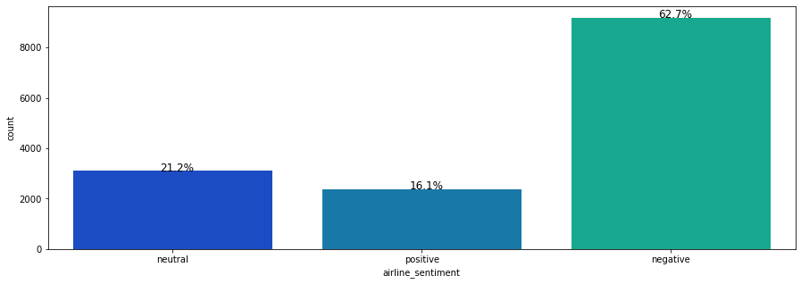

```python
plt.figure(figsize=(15,5))
ax = sns.countplot(data["airline_sentiment"],palette='winter')
perc_on_bar(ax,data["airline_sentiment"])
```

- About 63% are negative, 21% are neutral and 16 % are positive.
- Overall negative reviews are dominating.
- It shows majority of the airline cusomters are not happy with aireline services particularly when they are at airport.

```python
# To get the count of airlines unique values
data.airline.value_counts().reset_index(name='text')
```

|  | index | text |
| --- | --- | --- |
| 0 | United | 3822 |
| 1 | US Airways | 2913 |
| 2 | American | 2759 |
| 3 | Southwest | 2420 |
| 4 | Delta | 2222 |
| 5 | Virgin America | 504 |

- United is leading. Let us see the graphical representation.

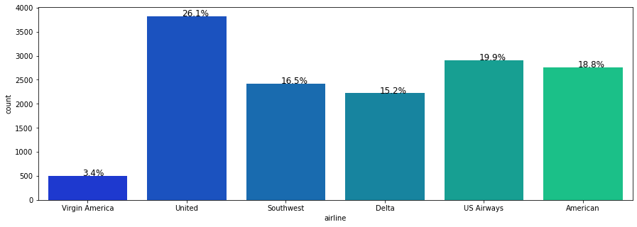

```python
plt.figure(figsize=(15,5))
ax = sns.countplot(data["airline"],palette='winter')
perc_on_bar(ax,data["airline"])
```

```python
# Get the count using groupby on airline and airline_sentiment
data.groupby(['airline', 'airline_sentiment']).agg({'airline_sentiment': ['count']})
```

| airline | airline_sentiment | airline_sentiment count |
| --- | --- | --- |
| American | negative | 1960 |
|  | neutral | 463 |
|  | positive | 336 |
| Delta | negative | 955 |
|  | neutral | 723 |
|  | positive | 544 |
| Southwest | negative | 1186 |
|  | neutral | 664 |
|  | positive | 570 |
| US Airways | negative | 2263 |
|  | neutral | 381 |
|  | positive | 269 |
| United | negative | 2633 |
|  | neutral | 697 |
|  | positive | 492 |
| Virgin America | negative | 181 |
|  | neutral | 171 |
|  | positive | 152 |

- Southwest has higher positive reviews compared to other airlines.
- All of the airlines have -ve reviews high in number.

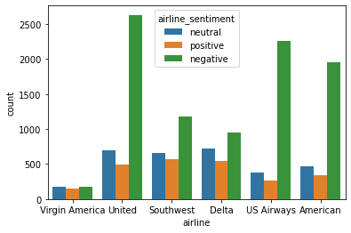

```python
# countplot to showcase airline and airline_sentiment.
sns.countplot(data['airline'], hue = data['airline_sentiment'])
plt.show()
```

- All of the airlines have -ve reviews leading.

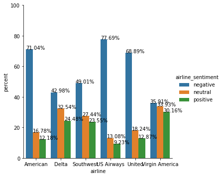

```python
# catplot to showcase % of airline and airline_sentiment
x,y = 'airline', 'airline_sentiment'

df1 = data.groupby(x)[y].value_counts(normalize=True)
df1 = df1.mul(100)
df1 = df1.rename('percent').reset_index()

g = sns.catplot(x=x,y='percent',hue=y,kind='bar',data=df1)
g.ax.set_ylim(0,100)

for p in g.ax.patches:
    txt = str(p.get_height().round(2)) + '%'
    txt_x = p.get_x()
    txt_y = p.get_height()
    g.ax.text(txt_x,txt_y,txt)
```

- All of the airlines have -ve reviews leading, followed by neutral rating.
- This shows that if service is not good, customers do not hesitate to use social media to share their outcry with fellow twitters.

```python
df2 = data[["airline","airline_sentiment"]]
df2 = df2.loc[df2['airline_sentiment'] == "negative"]
df2.value_counts()
```

```
airline         airline_sentiment
United          negative             2633
US Airways      negative             2263
American        negative             1960
Southwest       negative             1186
Delta           negative              955
Virgin America  negative              181
dtype: int64
```

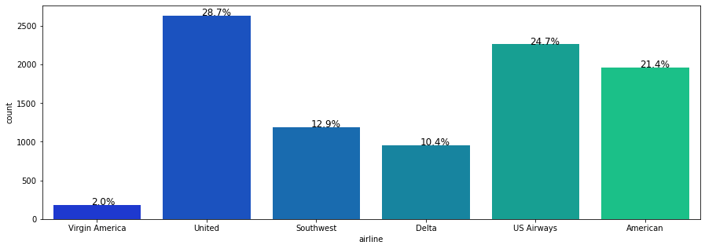

```python
plt.figure(figsize=(15,5))
ax = sns.countplot(df2["airline"],palette='winter')
perc_on_bar(ax,df2["airline"])
```

- The dataset has reviewes on United more followed by US Airways, American, Southwest, Delta and VA.
- The negative reviews also followed the same order. There is plenty of room for airlines to improve.
- But unfortunately there are many other factors influence customers sentiment, some of them may not be in airlines control.

#### Word Cloud for Negative Reviews

```python
#import list of stopwords from the NLTK library
from wordcloud import WordCloud,STOPWORDS
```

```python
#creating word cloud for negative reviews
negative_reviews=data[data['airline_sentiment'] == 'negative']
words = ' '.join(negative_reviews['text'])
cleaned_word = " ".join([word for word in words.split()])
```

```python
wordcloud = WordCloud(stopwords=STOPWORDS,
                      background_color='black',
                      width=3000,
                      height=2500
                     ).generate(cleaned_word)
```

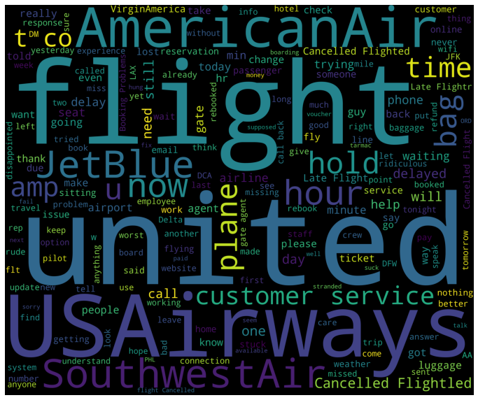

```python
plt.figure(1,figsize=(12, 12))
plt.imshow(wordcloud)
plt.axis('off')
plt.show()
```

- rediculous, delayed, stranded, wait, long, miss, never, bad, stuck, fail, back were some of the important recurring words observed in the negative reviews.

### Word Cloud for Positive Reviews

```python
#creating word cloud for positive reviews
positive_reviews=data[data['airline_sentiment'] == 'positive']
words = ' '.join(positive_reviews['text'])
cleaned_word = " ".join([word for word in words.split()])
```

```python
wordcloud = WordCloud(stopwords=STOPWORDS,
                      background_color='black',
                      width=3000,
                      height=2500
                     ).generate(cleaned_word)
```

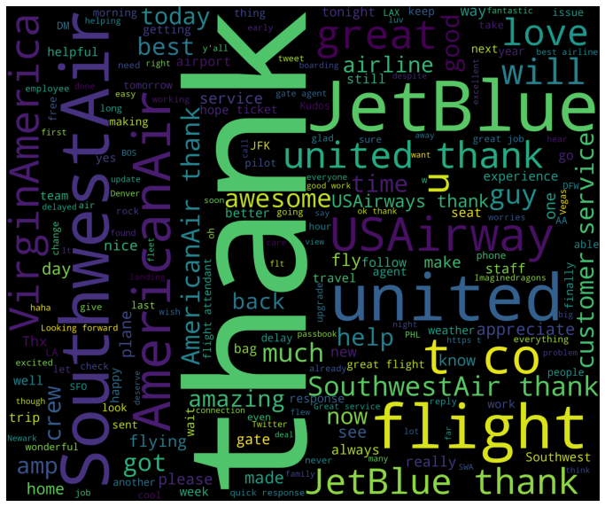

```python
plt.figure(1,figsize=(12, 12))
plt.imshow(wordcloud)
plt.axis('off')
plt.show()
```

- appreciate, experience, awesome, response, help, great, thank, love, care, helpful were some of the important recurring words observed in the positive reviews.
- Project Work: ##### Understanding of Data Columns
- Understand of data columns: (1.5 Marks) a. Drop all other columns except “text” and “airline_sentiment”. b. Check the shape of the data. c. Print the first 5 rows of data.
- Dropping the columns which have got too many missing values or does not relevent information
- These columns are dropped '''tweet_id,  
  airline_sentiment_confidence, negativereason, negativereason_confidence, airline, airline_sentiment_gold, name, negativereason_gold, retweet_count, tweet_coord, tweet_created, tweet_location, user_timezone'''

```python
# creating a dataset with text and airline_sentiment after dropping all the columns
df = data[['text','airline_sentiment']]
```

```python
# shape of the dataset after columns dropped
df.shape
```

```
(14640, 2)
```

- now the dataset has 14600 rows and 2 columns

```python
# top 5 rows from the dataset
df.head(5)
```

|  | text | airline_sentiment |
| --- | --- | --- |
| 0 | @VirginAmerica What @dhepburn said. | neutral |
| 1 | @VirginAmerica plus you've added commercials t... | positive |
| 2 | @VirginAmerica I didn't today... Must mean I n... | neutral |
| 3 | @VirginAmerica it's really aggressive to blast... | negative |
| 4 | @VirginAmerica and it's a really big bad thing... | negative |

- Project Work: #### Data Pre - Processing
- Text pre-processing: Data preparation. NOTE:- Each text pre-processing step should be mentioned in the notebook separately. a. Html tag removal. b. Tokenization. c. Remove the numbers. d. Removal of Special Characters and Punctuations. e. Removal of stopwords f. Conversion to lowercase. g. Lemmatize or stemming. h. Join the words in the list to convert back to text string in the data frame. (So that each row contains the data in text format.) i. Print the first 5 rows of data after pre-processing.

#### Data Pre-processing Steps:

- Remove html tags.
- Replace contractions in string. (e.g. replace I'm --> I am) and so on.
- Remove numbers.
- Tokenization.
- Remove Stopwords.
- Lemmatized data.
- Used the NLTK library to tokenize words, remove stopwords and lemmatize the remaining words.

```python
#remove the html tags
def strip_html(text):
    soup = BeautifulSoup(text, "html.parser")
    return soup.get_text()

#expand the contractions
def replace_contractions(text):
    """Replace contractions in string of text"""
    return contractions.fix(text)

#remove the numericals present in the text
def remove_numbers(text):
  text = re.sub(r'\d+', '', text)
  return text

def clean_text(text):
    text = strip_html(text)
    text = replace_contractions(text)
    text = remove_numbers(text)
    return text
df['text'] = df['text'].apply(lambda x: clean_text(x))
df.head()
```

|  | text | airline_sentiment |
| --- | --- | --- |
| 0 | @VirginAmerica What @dhepburn said. | neutral |
| 1 | @VirginAmerica plus you have added commercials... | positive |
| 2 | @VirginAmerica I did not today... Must mean I ... | neutral |
| 3 | @VirginAmerica it is really aggressive to blas... | negative |
| 4 | @VirginAmerica and it is a really big bad thin... | negative |

```python
df['text'] = df.apply(lambda row: nltk.word_tokenize(row['text']), axis=1) # Tokenization of df
df.head()
```

|  | text | airline_sentiment |
| --- | --- | --- |
| 0 | [@, VirginAmerica, What, @, dhepburn, said, .] | neutral |
| 1 | [@, VirginAmerica, plus, you, have, added, com... | positive |
| 2 | [@, VirginAmerica, I, did, not, today, ..., Mu... | neutral |
| 3 | [@, VirginAmerica, it, is, really, aggressive,... | negative |
| 4 | [@, VirginAmerica, and, it, is, a, really, big... | negative |

```python
from nltk.corpus import stopwords
stopwords = stopwords.words('english')
stopwords = list(set(stopwords))
print(stopwords)
```

```
["she's", "couldn't", 'll', "didn't", 'our', 'just', 'are', 'will', 'until', 'own', 'who', 'off', 'i', 'you', 'most', 'this', 'which', 'there', 'couldn', 'itself', 'she', 'ours', "it's", 'it', 'other', 'her', 'was', "won't", 'won', "mightn't", 'above', "mustn't", 'ourselves', 'doesn', "needn't", 'ha…
```

```python
lemmatizer = WordNetLemmatizer()

#remove the non-ASCII characters
def remove_non_ascii(words):
    """Remove non-ASCII characters from list of tokenized words"""
    new_words = []
    for word in words:
        new_word = unicodedata.normalize('NFKD', word).encode('ascii', 'ignore').decode('utf-8', 'ignore')
        new_words.append(new_word)
    return new_words

# convert all characters to lowercase
def to_lowercase(words):
    """Convert all characters to lowercase from list of tokenized words"""
    new_words = []
    for word in words:
        new_word = word.lower()
        new_words.append(new_word)
    return new_words

# Remove the punctuations
def remove_punctuation(words):
    """Remove punctuation from list of tokenized words"""
    new_words = []
    for word in words:
        new_word = re.sub(r'[^\w\s]', '', word)
        if new_word != '':
            new_words.append(new_word)
    return new_words

# Remove the stop words
def remove_stopwords(words):
    """Remove stop words from list of tokenized words"""
    new_words = []
    for word in words:
        if word not in stopwords:
            new_words.append(word)
    return new_words

# lemmatize the words
def lemmatize_list(words):
    new_words = []
    for word in words:
      new_words.append(lemmatizer.lemmatize(word, pos='v'))
    return new_words

def normalize(words):
    words = remove_non_ascii(words)
    words = to_lowercase(words)
    words = remove_punctuation(words)
    words = remove_stopwords(words)
    words = lemmatize_list(words)
    return ' '.join(words)

#data['review'] = data['review'].astype(str)
df['text'] = df.apply(lambda row: normalize(row['text']), axis=1)
```

```python
# top 5 rows after applying 'data Pre - Processing techniques.
df.head(5)
```

|  | text | airline_sentiment |
| --- | --- | --- |
| 0 | virginamerica dhepburn say | neutral |
| 1 | virginamerica plus add commercials experience ... | positive |
| 2 | virginamerica today must mean need take anothe... | neutral |
| 3 | virginamerica really aggressive blast obnoxiou... | negative |
| 4 | virginamerica really big bad thing | negative |

```python
df_Unsuper = df.copy()  # To use this for Unsupervised (Textblob and VADER) Learning methods for Sentiment Analysis
```

- Project Work: ##### Vectorization a. Use CountVectorizer. b. Use TfidfVectorizer. Apply count vectorizer, Tf-IDF vectorizer, on the required text column to make it suitable for fitting the model

##### Modeling, cross-validation, and Evaluation

Fit the model using vectorized column - Cross-validate the model performance - Evaluate the model using the confusion matrix - Target the final score >= 75% - Print the top 40 features and plot their word cloud using both types of vectorization.

#### Bag of Words (CountVectorizer)

In BoW, I constructed a dictionary that contains the set of all unique words from our text review dataset. The frequency of the word is counted here. If there are d unique words in our dictionary then for every review the vector will be of length d and count of word from reviews is stored at its particular location in vector. The vector will be highly sparse in such cases.

```python
# Vectorization (Convert text data to numbers).
from sklearn.feature_extraction.text import CountVectorizer

Count_vec = CountVectorizer(max_features=400)                # Keep only 500 features as number of features will increase the processing time.
data_features = Count_vec.fit_transform(df['text'])

data_features = data_features.toarray()
```

```python
data_features.shape       #Shape of the feature vector
```

```
(14640, 400)
```

```python
X = data_features

y = df.airline_sentiment
```

```python
# Split data into training and testing set.

from sklearn.model_selection import train_test_split

X_train, X_test, y_train, y_test = train_test_split(X, y, test_size=0.25, shuffle=False)
```

```python
# Finding optimal number of base learners using k-fold CV ->
base_ln = np.arange(100,400,100).tolist()
base_ln
```

```
[100, 200, 300]
```

```python
# K-Fold Cross - validation .
cv_scores = []
for b in base_ln:
    clf = RandomForestClassifier(n_estimators = b)
    scores = cross_val_score(clf, X_train, y_train, cv = 5, scoring = 'accuracy')
    cv_scores.append(scores.mean())
```

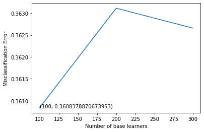

```python
# plotting the error as k increases
error = [1 - x for x in cv_scores]                                 #error corresponds to each nu of estimator
optimal_learners = base_ln[error.index(min(error))]                #Selection of optimal nu of n_estimator corresponds to minimum error.
plt.plot(base_ln, error)                                           #Plot between each nu of estimator and misclassification error
xy = (optimal_learners, min(error))
plt.annotate('(%s, %s)' % xy, xy = xy, textcoords='data')
plt.xlabel("Number of base learners")
plt.ylabel("Misclassification Error")
plt.show()
```

```python
# Training the best model and calculating accuracy on test data .
clf = RandomForestClassifier(n_estimators = optimal_learners)
clf.fit(X_train, y_train)
clf.score(X_test, y_test)
count_vectorizer_predicted = clf.predict(X_test)
print(classification_report(y_test ,count_vectorizer_predicted , target_names = ['postive' , 'negative', 'neutral']))
print("Accuracy of the model is : ",accuracy_score(y_test,count_vectorizer_predicted))
```

```
              precision    recall  f1-score   support

     postive       0.84      0.90      0.87      2627
    negative       0.49      0.35      0.41       577
     neutral       0.65      0.61      0.63       456

    accuracy                           0.78      3660
   macro avg       0.66      0.62      0.63      3660
weighted avg       0.76      0.78      0.77      3660

Accuracy of the model is :  0.7765027322404372
```

```
[[2363  166   98]
 [ 322  203   52]
 [ 131   49  276]]
```

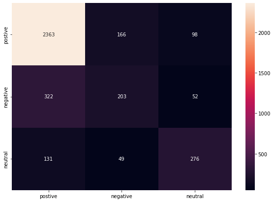

```python
# Print and plot Confusion matirx to get an idea of how the distribution of the prediction is, among all the classes.

import matplotlib.pyplot as plt
import seaborn as sns
from sklearn.metrics import confusion_matrix

conf_mat = confusion_matrix(y_test, count_vectorizer_predicted)

print(conf_mat)

df_cm = pd.DataFrame(conf_mat, index = [i for i in ['postive' , 'negative', 'neutral']],
                  columns = [i for i in ['postive' , 'negative', 'neutral']])
plt.figure(figsize = (10,7))
sns.heatmap(df_cm, annot=True, fmt='g')
```

**Word Cloud of top 40 important features from the CountVectorizer + Random Forest based model**

```
thank,usairways,http,jetblue,unite,flight,delay,great,love,get,southwestair,hours,bag,hold,awesome,cancel,fly,go,would,hour,time,make,virginamerica,please,help,need,wait,amaze,best,customer,service,good,plane,us,airline,say,call,one,guy,like,
```

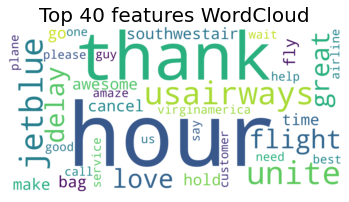

```python
all_features = Count_vec.get_feature_names()              #Instantiate the feature from the vectorizer
top_features=''                                            # Addition of top 40 feature into top_feature after training the model
feat=clf.feature_importances_
features=np.argsort(feat)[::-1]
for i in features[0:40]:
    top_features+=all_features[i]
    top_features+=','

print(top_features)

print(" ")
print(" ")

from wordcloud import WordCloud
wordcloud = WordCloud(background_color="white",colormap='viridis',width=2000,
                          height=1000).generate(top_features)

# Display the generated image:
plt.imshow(wordcloud, interpolation='bilinear')
plt.figure(1, figsize=(14, 11), frameon='equal')
plt.title('Top 40 features WordCloud', fontsize=20)
plt.axis("off")
plt.show()
```

##### TF-IDF

Term Frequency - Inverse Document Frequency: It makes sure that less importance is given to the most frequent words, and it also considers less frequent words.

```python
# Using TfidfVectorizer to convert text data to numbers.

from sklearn.feature_extraction.text import TfidfVectorizer

tfidf_vect = TfidfVectorizer(max_features=400)
data_features = tfidf_vect.fit_transform(df['text'])

data_features = data_features.toarray()

data_features.shape     #feature shape
```

```
(14640, 400)
```

```python
X = data_features

y = df.airline_sentiment
```

```python
# Split data into training and testing set.

from sklearn.model_selection import train_test_split

X_train, X_test, y_train, y_test = train_test_split(X, y, test_size=0.25, shuffle=False)
```

```python
# Finding optimal number of base learners using k-fold CV ->
base_ln = np.arange(100,400,100).tolist()
base_ln
```

```
[100, 200, 300]
```

```python
# K-Fold Cross - validation .
cv_scores = []
for b in base_ln:
    clf = RandomForestClassifier(n_estimators = b)
    scores = cross_val_score(clf, X_train, y_train, cv = 5, scoring = 'accuracy')
    cv_scores.append(scores.mean())
```

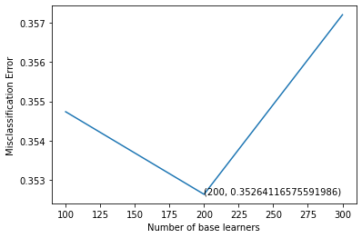

```python
# plotting the error as k increases
error = [1 - x for x in cv_scores]                                 #error corresponds to each nu of estimator
optimal_learners = base_ln[error.index(min(error))]                #Selection of optimal nu of n_estimator corresponds to minimum error.
plt.plot(base_ln, error)                                           #Plot between each nu of estimator and misclassification error
xy = (optimal_learners, min(error))
plt.annotate('(%s, %s)' % xy, xy = xy, textcoords='data')
plt.xlabel("Number of base learners")
plt.ylabel("Misclassification Error")
plt.show()
```

```python
# Training the best model and calculating accuracy on test data .
clf = RandomForestClassifier(n_estimators = optimal_learners)
clf.fit(X_train, y_train)
clf.score(X_test, y_test)
tf_idf_predicted = clf.predict(X_test)
print(classification_report(y_test , tf_idf_predicted , target_names = ['postive' , 'negative', 'neutral']))
print("Accuracy of the model is : ",accuracy_score(y_test,tf_idf_predicted))
```

```
              precision    recall  f1-score   support

     postive       0.81      0.95      0.87      2627
    negative       0.58      0.20      0.30       577
     neutral       0.69      0.58      0.63       456

    accuracy                           0.78      3660
   macro avg       0.69      0.58      0.60      3660
weighted avg       0.76      0.78      0.75      3660

Accuracy of the model is :  0.7841530054644809
```

```
[[2489   67   71]
 [ 410  117   50]
 [ 175   17  264]]
```

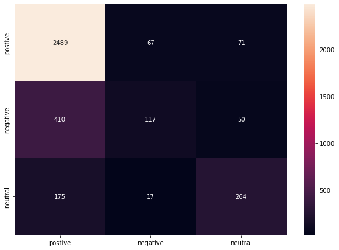

```python
# Print and plot Confusion matirx to get an idea of how the distribution of the prediction is, among all the classes.

import matplotlib.pyplot as plt
import seaborn as sns
from sklearn.metrics import confusion_matrix

conf_mat = confusion_matrix(y_test, tf_idf_predicted)

print(conf_mat)

df_cm = pd.DataFrame(conf_mat, index = [i for i in ['postive' , 'negative', 'neutral']],
                  columns = [i for i in ['postive' , 'negative', 'neutral']])
plt.figure(figsize = (10,7))
sns.heatmap(df_cm, annot=True, fmt='g')
```

- Word Cloud of top 40 important features from the TTfidfVectorizer + Random Forest based model

```
thank, southwestair, jetblue, unite, http, usairways, flight, great, virginamerica, delay, love, get, awesome, fly, please, cancel, bag, hold, amaze, hours, best, would, make, need, service, good, help, time, hour, dm, go, follow, wait, customer, know, us, airline, plane, tomorrow, hi,
```

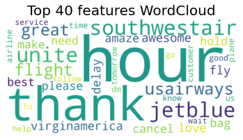

```python
all_features = tfidf_vect.get_feature_names()              #Instantiate the feature from the vectorizer
top_features=''                                            # Addition of top 40 feature into top_feature after training the model
feat=clf.feature_importances_
features=np.argsort(feat)[::-1]
for i in features[0:40]:
    top_features+=all_features[i]
    top_features+=', '

print(top_features)

print(" ")
print(" ")

from wordcloud import WordCloud
wordcloud = WordCloud(background_color="white",colormap='viridis',width=2000,
                          height=1000).generate(top_features)

# Display the generated image:
plt.imshow(wordcloud, interpolation='bilinear')
plt.figure(1, figsize=(14, 11), frameon='equal')
plt.title('Top 40 features WordCloud', fontsize=20)
plt.axis("off")
plt.show()
```

**Comparing the accuracies of Supervised Learning methods i.e Count Vectorizer and TF-IDF**

```python
#convert the test samples into a dataframe where the columns are
#the y_test(ground truth labels),tf-idf model predicted labels(tf_idf_predicted),Count Vectorizer model predicted labels(count_vectorizer_predicted)
df = pd.DataFrame(y_test.tolist(),columns =['y_test'])
df['count_vectorizer_predicted'] = count_vectorizer_predicted
df['tf_idf_predicted'] = tf_idf_predicted
df.tail()
```

|  | y_test | count_vectorizer_predicted | tf_idf_predicted |
| --- | --- | --- | --- |
| 3655 | positive | positive | positive |
| 3656 | negative | negative | negative |
| 3657 | neutral | positive | negative |
| 3658 | negative | negative | negative |
| 3659 | neutral | negative | negative |

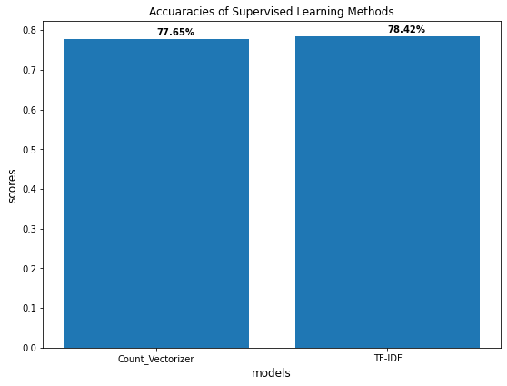

```python
#create bar plot to compare the accuaracies of Count Vectorizer and TF-IDF
import matplotlib.pyplot as plt
fig = plt.figure(figsize=(7,5))
ax = fig.add_axes([0,0,1,1])
subjects = ['Count_Vectorizer', 'TF-IDF']

# calculation accuracies of Count Vectorizer and TF-IDF using accuracy_score metrics
scores = [accuracy_score(y_test,count_vectorizer_predicted),accuracy_score(y_test,tf_idf_predicted)]
ax.bar(subjects,scores)
ax.set_ylabel('scores',fontsize= 12)    # y axis label
ax.set_xlabel('models',fontsize= 12)    # x axis label
ax.set_title('Accuaracies of Supervised Learning Methods')  # tittle
for i, v in enumerate(scores):
    ax.text( i ,v+0.01, '{:.2f}%'.format(100*v), color='black', fontweight='bold')
    plt.savefig('barplot_1.png',dpi=100, format='png', bbox_inches='tight')
plt.show()
```

- I was expecting more but the gap is less than 2%. **TF-IDF shows slightly better performance than Count Vectorizer**, because it not only focuses on the frequency of words present in the corpus but also provides the importance of the words. This helps to remove the words that are less important for analysis, hence making the model building less complex by reducing the input dimensions.

### Unsupervised Learning methods for Sentiment Analysis (Optional)

#### TextBlob

```python
from textblob import TextBlob
```

```python
df_Unsuper.head
```

```
<bound method NDFrame.head of                                                     text airline_sentiment
0                             virginamerica dhepburn say           neutral
1      virginamerica plus add commercials experience ...          positive
2      virginamerica today must mean need take anothe...           neutral
3      virginamerica really aggressive blast obnoxiou...          negative
4                     virginamerica really big bad thing          negative
...                                                  ...               ...
14635     americanair thank get different flight chicago          positive
14636  americanair leave minutes late flight warn com...          negative
14637  americanair please bring american airlines bla...           neutral
14638  americanair money change flight answer phone s...          negative
14639  americanair people need know many seat next fl...           neutral

[14640 rows x 2 columns]>
```

```python
#Calculate the polarity score of the reviews
df_Unsuper['polarity']  = df_Unsuper['text'].apply(lambda text: TextBlob(text).sentiment.polarity)

df_Unsuper.head()
```

|  | text | airline_sentiment | polarity |
| --- | --- | --- | --- |
| 0 | virginamerica dhepburn say | neutral | 0.00000 |
| 1 | virginamerica plus add commercials experience ... | positive | 0.00000 |
| 2 | virginamerica today must mean need take anothe... | neutral | -0.31250 |
| 3 | virginamerica really aggressive blast obnoxiou... | negative | 0.00625 |
| 4 | virginamerica really big bad thing | negative | -0.35000 |

```python
# function to convert polarity score into text (positive, negative and neutral)
def getAnalysis(score):
  if score < 0:
    return 'negative'
  elif score == 0:
    return 'neutral'
  else:
    return 'positive'
```

```python
#Classify the class of the review by keeping threshold on the polarity score
df_Unsuper['polarity_score'] = df_Unsuper['polarity'].apply(getAnalysis)

df_Unsuper.head()
```

|  | text | airline_sentiment | polarity | polarity_score |
| --- | --- | --- | --- | --- |
| 0 | virginamerica dhepburn say | neutral | 0.00000 | neutral |
| 1 | virginamerica plus add commercials experience ... | positive | 0.00000 | neutral |
| 2 | virginamerica today must mean need take anothe... | neutral | -0.31250 | negative |
| 3 | virginamerica really aggressive blast obnoxiou... | negative | 0.00625 | positive |
| 4 | virginamerica really big bad thing | negative | -0.35000 | negative |

```python
df_Unsuper["Text_Blob_pred"] = df_Unsuper['polarity_score'].tolist()
df_Unsuper.head()
```

|  | text | airline_sentiment | polarity | polarity_score | Text_Blob_pred |
| --- | --- | --- | --- | --- | --- |
| 0 | virginamerica dhepburn say | neutral | 0.00000 | neutral | neutral |
| 1 | virginamerica plus add commercials experience ... | positive | 0.00000 | neutral | neutral |
| 2 | virginamerica today must mean need take anothe... | neutral | -0.31250 | negative | negative |
| 3 | virginamerica really aggressive blast obnoxiou... | negative | 0.00625 | positive | positive |
| 4 | virginamerica really big bad thing | negative | -0.35000 | negative | negative |

```python
print("Accuaracy of using Text Blob Sentiment Analysis is : ",
      accuracy_score(df_Unsuper["airline_sentiment"].tolist(),df_Unsuper["Text_Blob_pred"].tolist()))
```

```
Accuaracy of using Text Blob Sentiment Analysis is :  0.41174863387978144
```

```
[[2654 3876 2648]
 [ 256 1908  935]
 [ 102  795 1466]]
```

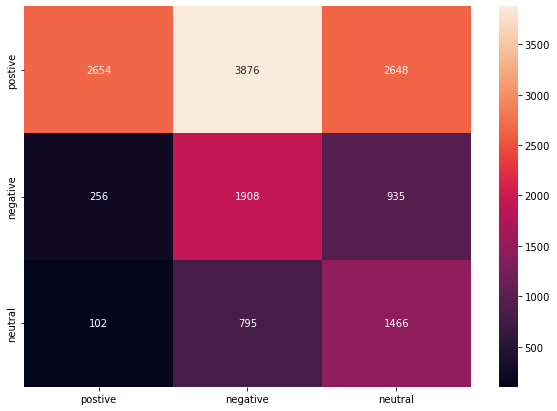

```python
# Print and plot Confusion matirx to get an idea of how the distribution of the prediction is, among all the classes.

import matplotlib.pyplot as plt
import seaborn as sns
from sklearn.metrics import confusion_matrix

conf_mat = confusion_matrix(df_Unsuper["airline_sentiment"].tolist(), df_Unsuper['Text_Blob_pred'].tolist())

print(conf_mat)

df_cm = pd.DataFrame(conf_mat, index = [i for i in ['postive' , 'negative', 'neutral']],
                  columns = [i for i in ['postive' , 'negative', 'neutral']])
plt.figure(figsize = (10,7))
sns.heatmap(df_cm, annot=True, fmt='g')
```

##### VADER

VADER (Valence Aware Dictionary and Sentiment Reasoner) is a lexicon and rule-based sentiment analysis tool. VADER not only tells us about the Positivity and Negativity score, but also tells us how positive or negative a sentiment is.

```python
import nltk
# download vader lexicon
# nltk.download('vader_lexicon')
from nltk.sentiment.vader import SentimentIntensityAnalyzer

sentiment = SentimentIntensityAnalyzer()
```

```python
#Calculate the polarity score of the reviews
df_Unsuper['scores'] = df_Unsuper['text'].apply(lambda text: sentiment.polarity_scores(text))

df_Unsuper.head()
```

|  | text | airline_sentiment | polarity | polarity_score | Text_Blob_pred | scores |
| --- | --- | --- | --- | --- | --- | --- |
| 0 | virginamerica dhepburn say | neutral | 0.00000 | neutral | neutral | {'neg': 0.0, 'neu': 1.0, 'pos': 0.0, 'compound... |
| 1 | virginamerica plus add commercials experience ... | positive | 0.00000 | neutral | neutral | {'neg': 0.0, 'neu': 1.0, 'pos': 0.0, 'compound... |
| 2 | virginamerica today must mean need take anothe... | neutral | -0.31250 | negative | negative | {'neg': 0.0, 'neu': 1.0, 'pos': 0.0, 'compound... |
| 3 | virginamerica really aggressive blast obnoxiou... | negative | 0.00625 | positive | positive | {'neg': 0.345, 'neu': 0.468, 'pos': 0.187, 'co... |
| 4 | virginamerica really big bad thing | negative | -0.35000 | negative | negative | {'neg': 0.486, 'neu': 0.514, 'pos': 0.0, 'comp... |

```python
#Calculate the compund score of the reviews
df_Unsuper['compound']  = df_Unsuper['scores'].apply(lambda score_dict: score_dict['compound'])

df_Unsuper.head()
```

|  | text | airline_sentiment | polarity | polarity_score | Text_Blob_pred | scores | compound |
| --- | --- | --- | --- | --- | --- | --- | --- |
| 0 | virginamerica dhepburn say | neutral | 0.00000 | neutral | neutral | {'neg': 0.0, 'neu': 1.0, 'pos': 0.0, 'compound... | 0.0000 |
| 1 | virginamerica plus add commercials experience ... | positive | 0.00000 | neutral | neutral | {'neg': 0.0, 'neu': 1.0, 'pos': 0.0, 'compound... | 0.0000 |
| 2 | virginamerica today must mean need take anothe... | neutral | -0.31250 | negative | negative | {'neg': 0.0, 'neu': 1.0, 'pos': 0.0, 'compound... | 0.0000 |
| 3 | virginamerica really aggressive blast obnoxiou... | negative | 0.00625 | positive | positive | {'neg': 0.345, 'neu': 0.468, 'pos': 0.187, 'co... | -0.3306 |
| 4 | virginamerica really big bad thing | negative | -0.35000 | negative | negative | {'neg': 0.486, 'neu': 0.514, 'pos': 0.0, 'comp... | -0.5829 |

```python
#Classify the class of the review by keeping threshold on the compund score
df_Unsuper['comp_score'] = df_Unsuper['compound'].apply(getAnalysis)

df_Unsuper.head()
```

|  | text | airline_sentiment | polarity | polarity_score | Text_Blob_pred | scores | compound | comp_score |
| --- | --- | --- | --- | --- | --- | --- | --- | --- |
| 0 | virginamerica dhepburn say | neutral | 0.00000 | neutral | neutral | {'neg': 0.0, 'neu': 1.0, 'pos': 0.0, 'compound... | 0.0000 | neutral |
| 1 | virginamerica plus add commercials experience ... | positive | 0.00000 | neutral | neutral | {'neg': 0.0, 'neu': 1.0, 'pos': 0.0, 'compound... | 0.0000 | neutral |
| 2 | virginamerica today must mean need take anothe... | neutral | -0.31250 | negative | negative | {'neg': 0.0, 'neu': 1.0, 'pos': 0.0, 'compound... | 0.0000 | neutral |
| 3 | virginamerica really aggressive blast obnoxiou... | negative | 0.00625 | positive | positive | {'neg': 0.345, 'neu': 0.468, 'pos': 0.187, 'co... | -0.3306 | negative |
| 4 | virginamerica really big bad thing | negative | -0.35000 | negative | negative | {'neg': 0.486, 'neu': 0.514, 'pos': 0.0, 'comp... | -0.5829 | negative |

```python
df_Unsuper["VADER_pred"] = df_Unsuper['comp_score'].tolist()
df_Unsuper.head()
```

|  | text | airline_sentiment | polarity | polarity_score | Text_Blob_pred | scores | compound | comp_score | VADER_pred |
| --- | --- | --- | --- | --- | --- | --- | --- | --- | --- |
| 0 | virginamerica dhepburn say | neutral | 0.00000 | neutral | neutral | {'neg': 0.0, 'neu': 1.0, 'pos': 0.0, 'compound... | 0.0000 | neutral | neutral |
| 1 | virginamerica plus add commercials experience ... | positive | 0.00000 | neutral | neutral | {'neg': 0.0, 'neu': 1.0, 'pos': 0.0, 'compound... | 0.0000 | neutral | neutral |
| 2 | virginamerica today must mean need take anothe... | neutral | -0.31250 | negative | negative | {'neg': 0.0, 'neu': 1.0, 'pos': 0.0, 'compound... | 0.0000 | neutral | neutral |
| 3 | virginamerica really aggressive blast obnoxiou... | negative | 0.00625 | positive | positive | {'neg': 0.345, 'neu': 0.468, 'pos': 0.187, 'co... | -0.3306 | negative | negative |
| 4 | virginamerica really big bad thing | negative | -0.35000 | negative | negative | {'neg': 0.486, 'neu': 0.514, 'pos': 0.0, 'comp... | -0.5829 | negative | negative |

```python
print("Accuaracy using Vader Sentiment Analysis is : ",
              accuracy_score(df_Unsuper["airline_sentiment"].tolist(),df_Unsuper["VADER_pred"].tolist()))
```

```
Accuaracy using Vader Sentiment Analysis is :  0.5084699453551913
```

```
[[4087 1934 3157]
 [ 408 1284 1407]
 [  88  202 2073]]
```

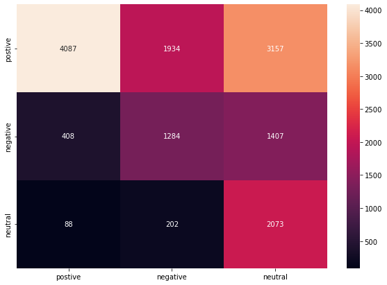

```python
# Print and plot Confusion matirx to get an idea of how the distribution of the prediction is, among all the classes.

import matplotlib.pyplot as plt
import seaborn as sns
from sklearn.metrics import confusion_matrix

conf_mat = confusion_matrix(df_Unsuper["airline_sentiment"].tolist(), df_Unsuper['VADER_pred'].tolist())

print(conf_mat)

df_cm = pd.DataFrame(conf_mat, index = [i for i in ['postive' , 'negative', 'neutral']],
                  columns = [i for i in ['postive' , 'negative', 'neutral']])
plt.figure(figsize = (10,7))
sns.heatmap(df_cm, annot=True, fmt='g')
```

#### **Comparing the accuracies of Unsupervised Learning methods VADER and TextBlob**

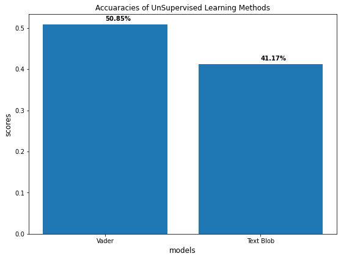

```python
#plot the accuaracies of the text blob and Vader
import matplotlib.pyplot as plt
fig = plt.figure(figsize=(7,5))
ax = fig.add_axes([0,0,1,1])
subjects = ['Vader', 'Text Blob']
# calculation accuracies of Vader and Textblob models using accuracy_score metrics
scores = [accuracy_score(df_Unsuper["airline_sentiment"].tolist(),df_Unsuper["VADER_pred"].tolist()),accuracy_score(df_Unsuper["airline_sentiment"].tolist(),df_Unsuper["Text_Blob_pred"].tolist())]
ax.bar(subjects,scores)
ax.set_ylabel('scores',fontsize= 12)   # y-axis labels
ax.set_xlabel('models',fontsize= 12)   # x-axis labels
ax.set_title('Accuaracies of UnSupervised Learning Methods')   #tittle of the graph
for i, v in enumerate(scores):
    ax.text( i ,v+0.01, '{:.2f}%'.format(100*v), color='black', fontweight='bold')
    plt.savefig('barplot_1.png',dpi=100, format='png', bbox_inches='tight')
plt.show()
```

- Vader (51%) performed much better than Text Blob (41%)
- Project Work: #### Conclusion
- Summary from the understanding of the application of Various Pre-processing, Vectorization, and performance of the model on the dataset.